# Eating Out

Desmond Koutso

`summer 2022`

# 1 The data comes from the 1998 General Social Survey answer this question

$H_0$ There is no difference among the various races with frequency of eating out  
$H_A$ There is a statistical difference between at least two races with the frequency of eating out

# 2 METHODS

response variable is catergorical: dine out last week? yes or no

explanatory variable is race, it , too, is a categorical variable.  
so we use cat~cat.

# 3 Descriptive summaries

## 3.1 Graphical summary

### 3.1.1 barchart

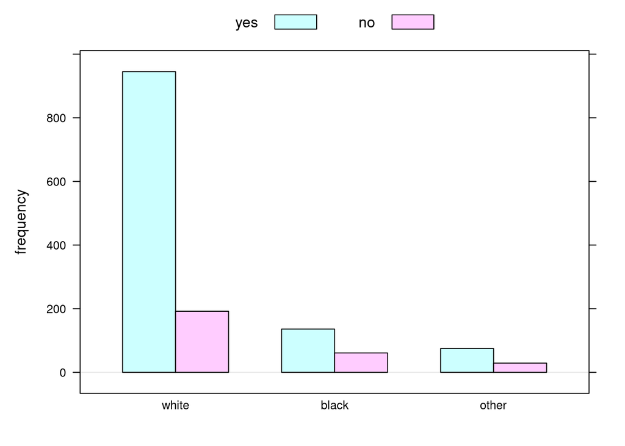

```r
barchartGC(~race + eatout,data=mydata)
```

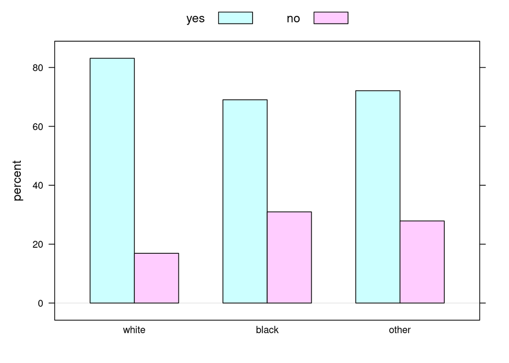

```r
barchartGC(~race + eatout,data=mydata, type="percent")
```

This plot shows that the percentage of white that eatout is greater than the percentage of black and other races.